# Niche construction model with flammability and fire-suppression

Hermina

# Introduction

Fire can restructure ecosystems because some species tend to be fire-prone (e.g., accumulate highly flammable biomass, grow quickly after fire, may even require fire to germinate) while others can be fire-resistant or even fire-retardant (“fire fighting”). This is called a feedback, here between vegetation type and fire probability.

Fire-facilitating and fire-inhibiting species are both ecosystem engineers that can lead to mutual exclusion under some conditions and coexistence under other conditions. Coexistence depends on the environmentaly-determined frequency of fire and whether/how fire frequency is impacted by vegetation-fire feedbacks.

Here I am coding (and simplifying) the model of [Beckage, Platt, & Gross 2009](https://www.journals.uchicago.edu/doi/10.1086/648458). Their model has 3 species but I am simplifying it to just 2.

Some notes: Although the paper above talks about savannas, the following biomes are also [pre-climate change] fire-dependent: boreal/taiga forest (for Siberian Taiga, this seems like once every 10 years) < shrublands < grasslands (of which savanna is an example).  
[see this paper for some recent remote sensing data on tropical savannas](https://www.sciencedirect.com/science/article/pii/S1569843223003990). These comprise $\approx 70$% of the total area that is burned on Earth and fires can easily happen annually (e.g., the paper above looks at 1km pixels and considers <40 active fires per year as too low; max of their data is >200 fires per year).

# The model

We have 2 species, a grass ($G$) and a tree ($A$), which are both self-limiting. Trees grow slower than grass ($\lambda<1$) but grass growth is limited by trees (i.e., whereas tree growth is *not* limited by grass). Fires occur at some constant rate determined by the environment ($\epsilon$). Fires can also occur more frequently through positive feedback proportional to the grass biomass and the flammability of the grass ($\phi \in [0,1)$) or more rarely through negative feedback proportional to the tree biomass and the fire suppression strength of the trees ($\rho \in [0,1)$). Finally, when a fire occurs, the fraction of biomass lost depends on $\mu \in (0,1)$ and can differ between trees ($\mu_A$) versus grass ($\mu_G$).

$$\begin{align}
\frac{dA}{dt} &= \lambda A(1-A) -\mu_A A (\epsilon + \phi G)(1-\rho
A),\\
\frac{dG}{dt} &= G(1-G-A) -\mu_G G (\epsilon + \phi G)(1-\rho A),
\end{align}$$

where $T, G \in (0,1)$. One question: confirm that $T + G \neq 1$. We can initialize the model using relative abundance but, annoyingly enough, it seems that the total biomass is not capped at 1.0…

The units of time ($t$) are relative to the (implicitly defined) growth rate of grass. Let’s say the unit of $t$ is month, that way $\epsilon = 0.01$ corresponds with $\approx 1$ fire every 8 years.

TO DO eventually: figure out a diagram for this s.t. it’s easy for students to sketch the model

Show a bit of the code so that students can get an idea of what it looks like:

```r
# define the model
#' @param time vector of time units over which to run model
#' @param init initial tree and grass biomass
#' @param params: lambda (growth rate of trees relative to grass),
#' epsilon (constant, environmentaly determined rate of fire),
#' phi (grass flammability), rho (tree fire suppression), and
#' fraction of biomass lost to fire for trees (mu_A) or grass (mu_G)
ODE <- function(time, init, params) {
  with (as.list(c(time, init, params)), {
    # define the differential equations:
    dA_dt = lambda*A*(1-A) - mu_A*A*(epsilon + phi*G)*(1-rho*A)
    dG_dt = G*(1-G-A) - mu_G*G*(epsilon + phi*G)*(1-rho*A)
    return(list(c(dA = dA_dt, dG = dG_dt)))
  })
}
```

## Code

```r
# a function to run forward time simulations
run_ODE_model <- function(time, init, params) {
  # check for fully neutral system
  #if (...) {
    # it's trivial to simulate the neutral dynamics:
  #} else {
    # solve the system of ODE's for the requested time points:
    data.frame(ode(func = ODE, y = init, parms = params, times = time, method="ode23"))
  #}
}

# a function to plot biomass over time
plot_time_relAbund <- function(sim_df, params, title_text=NA){
  # convert from absolute abundance to relative abundances
  sim_df$relA <- sim_df$A / (sim_df$A + sim_df$G)
  sim_df$relG <- sim_df$G / (sim_df$A + sim_df$G)

  # change the data.frame from wide format to long format for plotting
  sim_df_long <- sim_df %>% select(-A, -G) %>% rename(Trees = relA, Grass = relG) %>%
                  pivot_longer(cols = !time, names_to = "Group") %>%
                    mutate(Group = factor(Group, levels = c("Trees", "Grass")))
  # plot
  ggplot(sim_df_long) +
    geom_line(aes(x = time, y = value, colour = Group)) +
    scale_colour_manual(values = colours_tree_grass) +
    labs(y = "Relative Abundance", x = "Time (months)",
         title = ifelse(is.na(title_text),
                        paste(params, collapse = ", "),
                        title_text) ) +
    scale_y_continuous(limits = c(-0.01, 1.01), expand = c(0, 0)) # important to set expand to 0,0 otherwise there's extra padding that makes it look like things aren't going to 0 or 1
}
```

# Exploring the model

Below I’m going to run some test cases to explore parameter combinations and resultant outcomes.

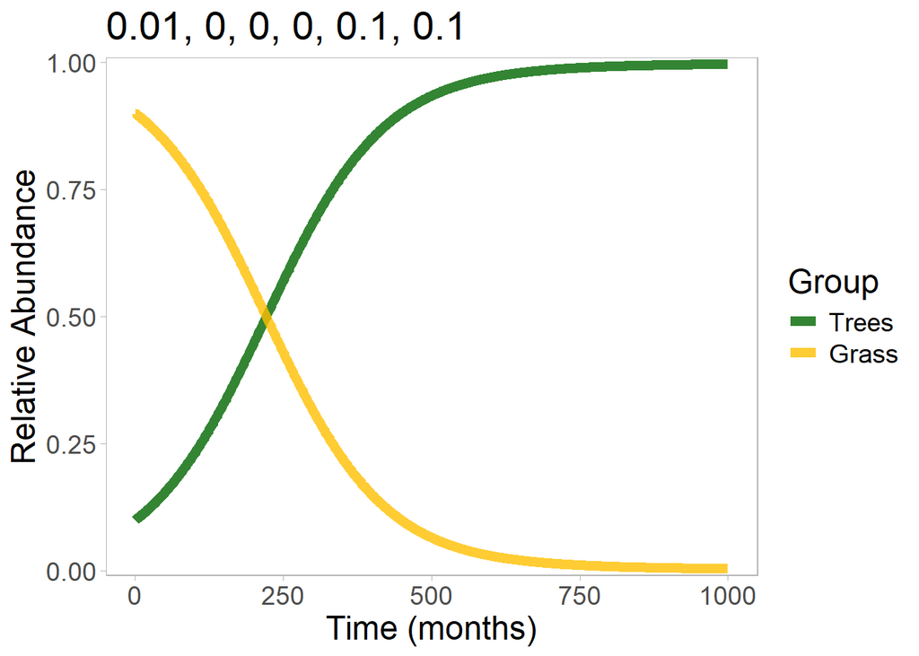

```r
time_vec <- seq(from=1, to=1000, by=1)
init_mostlytrees <- c(A=0.9, G=0.1)
init_mostlygrass <- c(A=0.1, G=0.9)


# trees dominate the ecosystem in the absence of fire
pars_temp <- c(lambda=0.01, epsilon=0, phi=0, rho=0, mu_A=0.1, mu_G=0.1)

run_ODE_model(time = time_vec,
              init = init_mostlygrass,
              params = pars_temp) %>%
    plot_time_relAbund(., pars_temp)
```

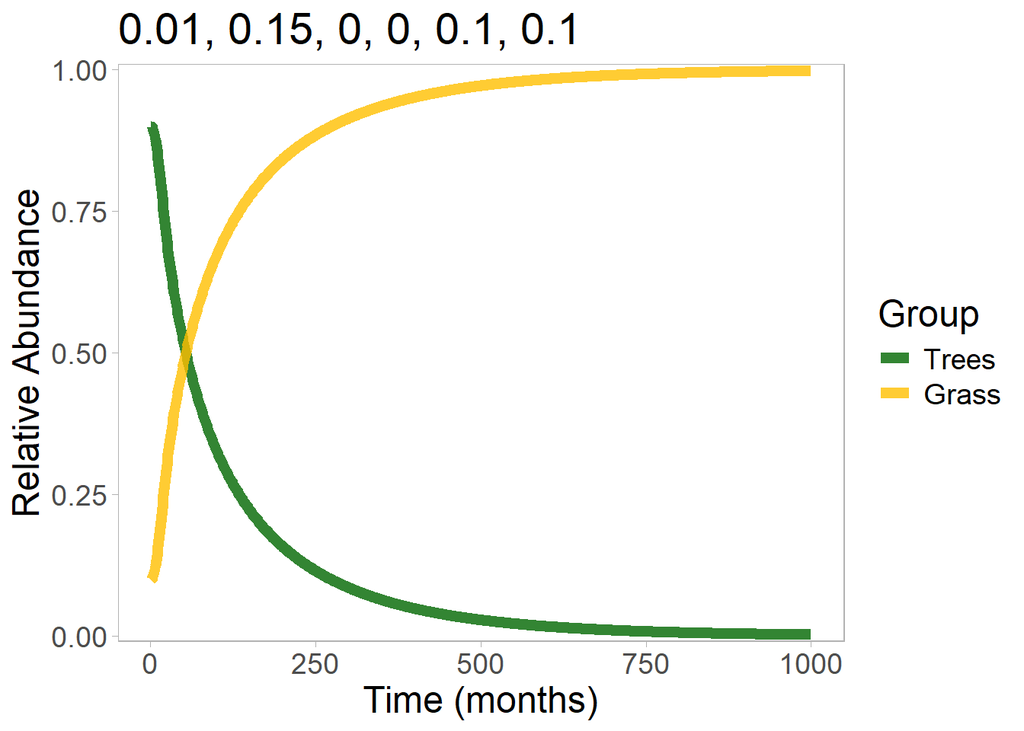

```r
# sufficiently frequent fires are an environmental driver:
# it shifts the ecosystem to grass dominated
pars_temp <- c(lambda=0.01, epsilon=0.15, phi=0, rho=0, mu_A=0.1, mu_G=0.1)

run_ODE_model(time = time_vec,
              init = init_mostlytrees,
              params = pars_temp) %>%
    plot_time_relAbund(., pars_temp)
```

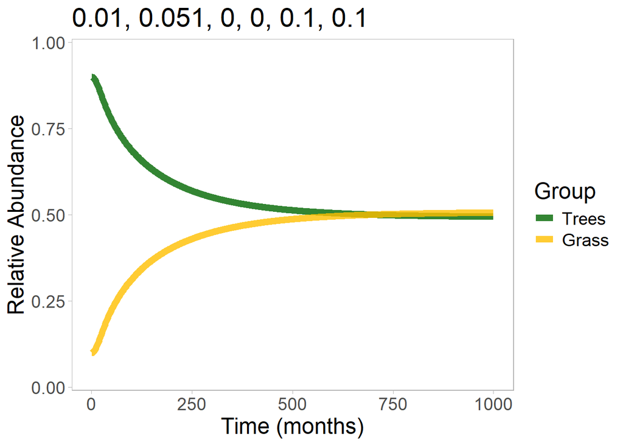

```r
# intermediate fire frequency leads to coexistence
pars_temp <- c(lambda=0.01, epsilon=0.051, phi=0, rho=0, mu_A=0.1, mu_G=0.1)

run_ODE_model(time = time_vec,
              init = init_mostlytrees,
              params = pars_temp) %>%
    plot_time_relAbund(., pars_temp)
```

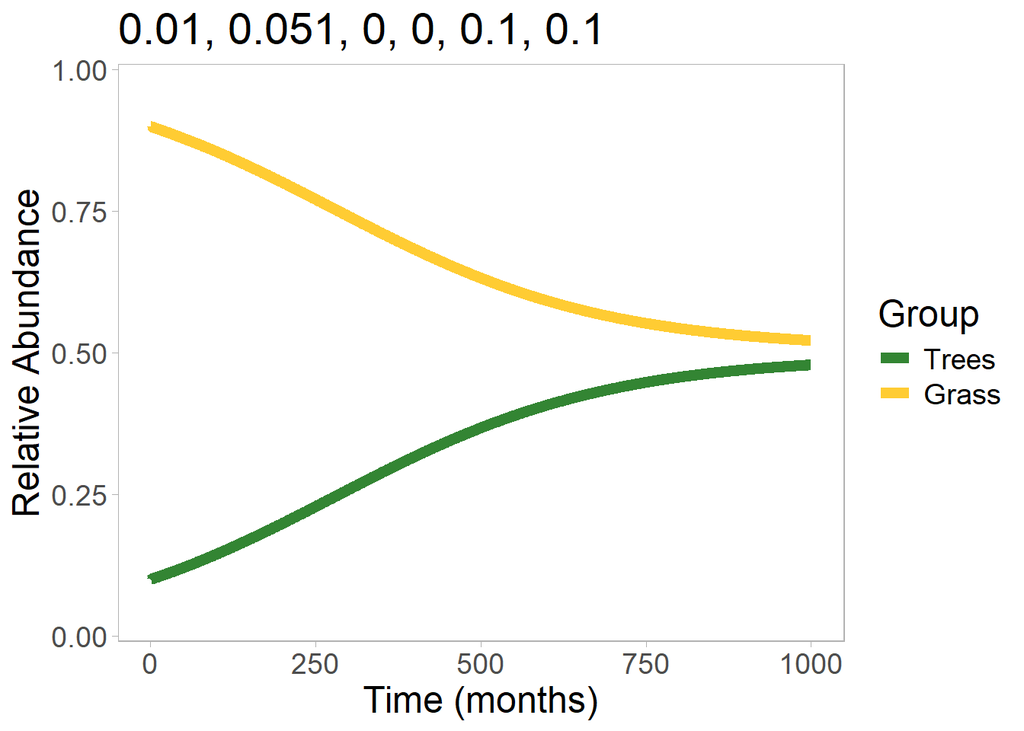

```r
run_ODE_model(time = time_vec,
              init = init_mostlygrass,
              params = pars_temp) %>%
    plot_time_relAbund(., pars_temp)
```

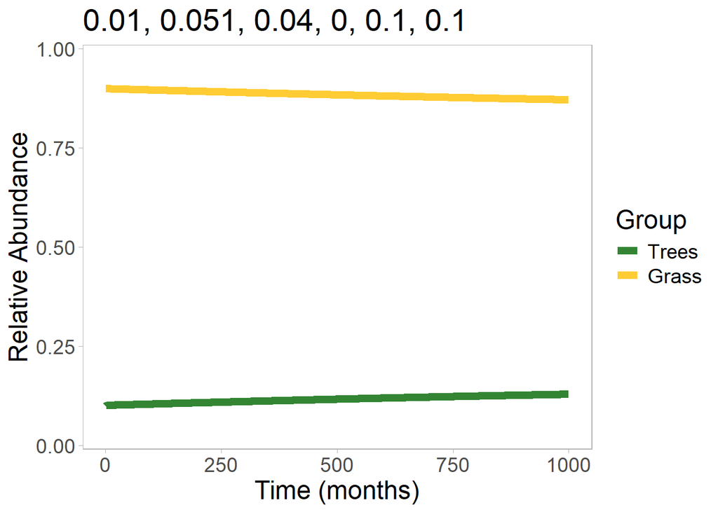

```r
# grass-fire positive feedback shifts the coexistence in favour of grasses
pars_temp <- c(lambda=0.01, epsilon=0.051, phi=0.04, rho=0, mu_A=0.1, mu_G=0.1)
run_ODE_model(time = time_vec,
              init = init_mostlygrass,
              params = pars_temp) %>%
    plot_time_relAbund(., pars_temp)
```

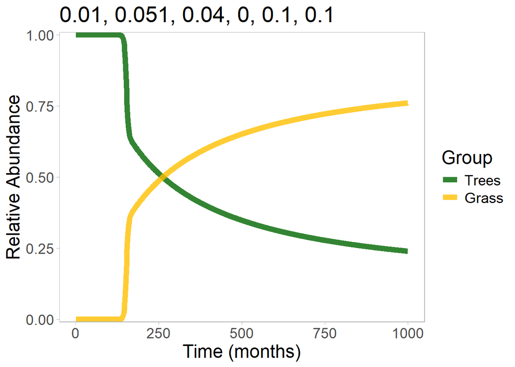

```r
# but trees cannot hold off grass invasion
run_ODE_model(time = time_vec,
              init = c(A=0.999, G=1e-15),
              params = pars_temp) %>%
    plot_time_relAbund(., pars_temp)
```

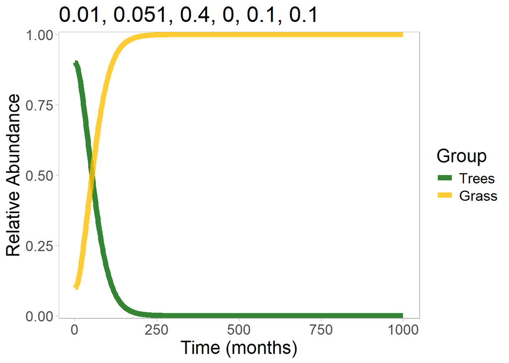

```r
# sufficiently strong grass-fire positive feedback leads to grass dominance
pars_temp <- c(lambda=0.01, epsilon=0.051, phi=0.4, rho=0, mu_A=0.1, mu_G=0.1)
run_ODE_model(time = time_vec,
              init = init_mostlytrees,
              params = pars_temp) %>%
    plot_time_relAbund(., pars_temp)
```

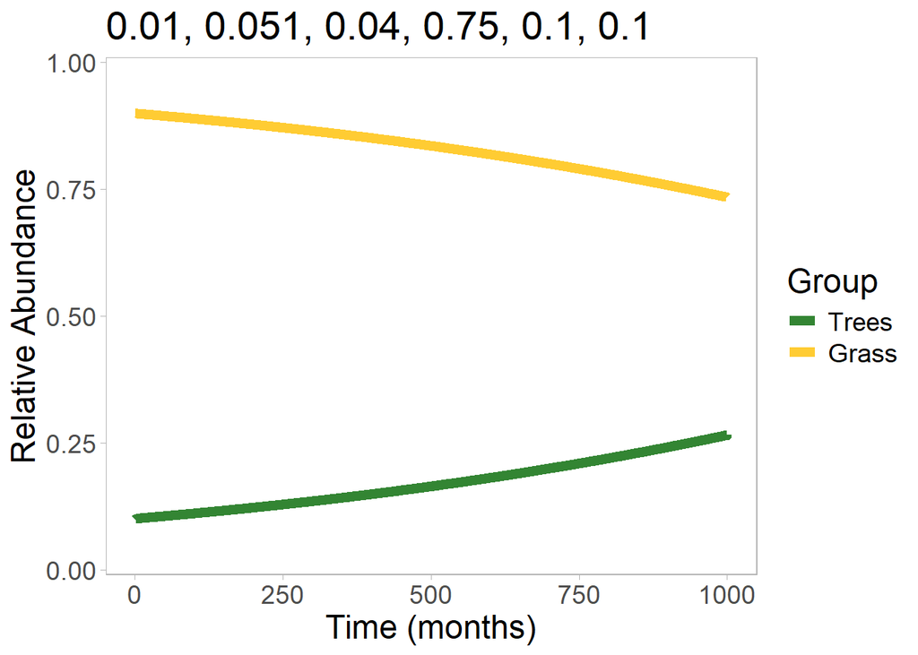

```r
# adding tree-fire negative feedback shifts the coexistence in favour of trees
pars_temp <- c(lambda=0.01, epsilon=0.051, phi=0.04, rho=0.75, mu_A=0.1, mu_G=0.1)
run_ODE_model(time = time_vec,
              init = init_mostlygrass,
              params = pars_temp) %>%
    plot_time_relAbund(., pars_temp)
```

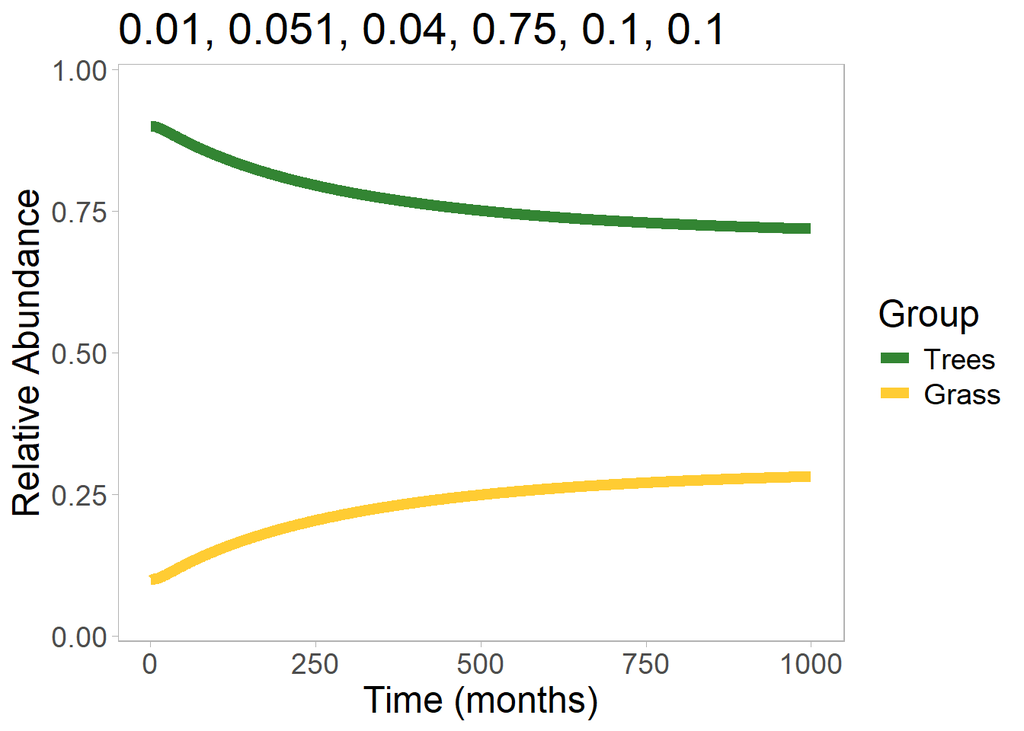

```r
run_ODE_model(time = time_vec,
              init = init_mostlytrees,
              params = pars_temp) %>%
    plot_time_relAbund(., pars_temp)
```

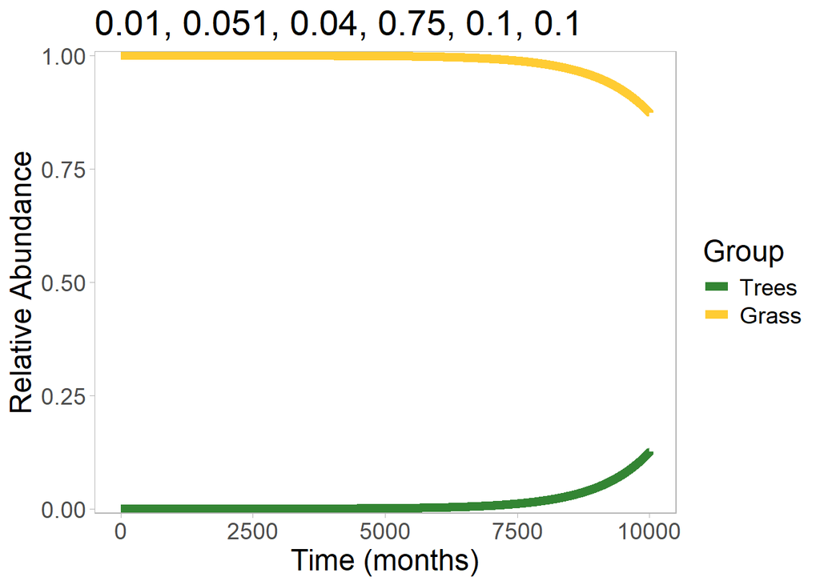

```r
# I think grass cannot hold off tree invasion indefinitely
run_ODE_model(time = 1:10000,
              init = c(A=1e-5, G=0.999),
              params = pars_temp) %>%
    plot_time_relAbund(., pars_temp)
```

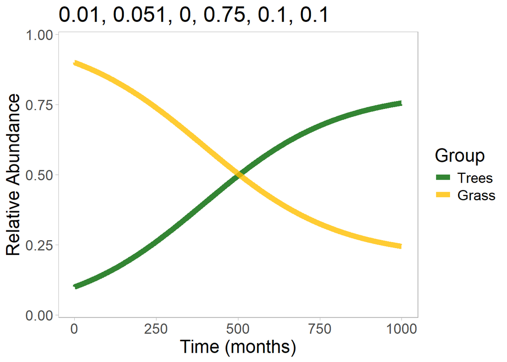

```r
# only tree-fire negative feedback with environmental driver
  # shifts to coexistence in favour of trees
pars_temp <- c(lambda=0.01, epsilon=0.051, phi=0, rho=0.75, mu_A=0.1, mu_G=0.1)
run_ODE_model(time = time_vec,
              init = init_mostlygrass,
              params = pars_temp) %>%
    plot_time_relAbund(., pars_temp)
```

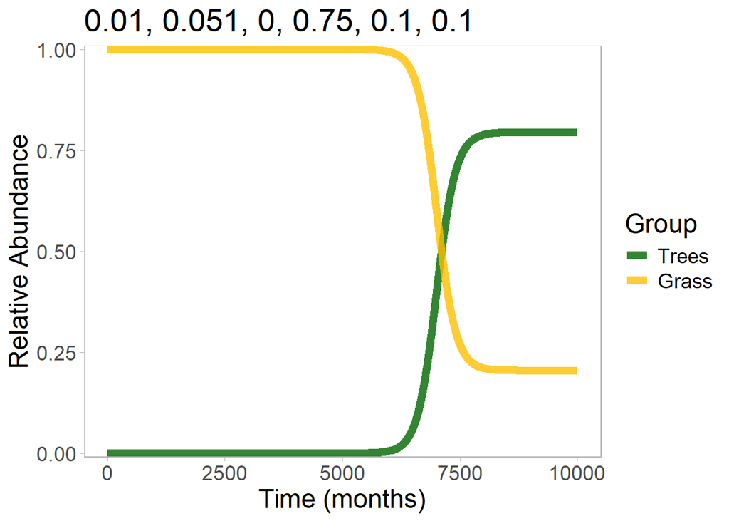

```r
# grass cannot hold off tree invasion indefinitely
run_ODE_model(time = 1:10000,
              init = c(A=1e-15, G=0.999),
              params = pars_temp) %>%
    plot_time_relAbund(., pars_temp)
```